# Practical Machine Learning Final Project

## Keith Gudger

### Analysis of data from accelerometers on the belt, forearm, arm, and dumbell of 6 participants. They were asked to perform barbell lifts correctly and incorrectly in 5 different ways.

Read in the data sets first.

```r
train <- read.csv("../pml-training.csv")
library(caret)
```

Then setup some training and testing partitions with seed (7640) and bootstrapping to create partitions.

```r
set.seed(7640)
inTrain <- createResample(y=train$classe,times=1,list=FALSE)
training <- train[inTrain,]
testing <- train[-inTrain,]
```

The “testing” set is a cross validation set. It is processed identically to the training set so that predictions with the final model will be the same. The goal is for an accuracy of 95%. Each model is evaluated with the cross validation set and results presented below.

It’s good to know which features are important. The code below looks for features with near zero variance and removes them.

```r
nsv <- nearZeroVar(training,saveMetrics=TRUE)
namedf <- subset(nsv,nzv==FALSE) # find all the relevant features' rows
nameList <- row.names(namedf) # all the relevant names
training2 <- training[,nameList] # new df with just relevant features
training2$classe <- training$classe # add outcome
out <- paste0("The total number of non-zero variance variables is ", length(nameList), " out of ",(length(names(training))-1), " original variables")
print(out)
```

```
## [1] "The total number of non-zero variance variables is 116 out of 159 original variables"
```

```r
testing2 <- testing[,nameList] # new df with just relevant features repeated on test set
testing2$classe <- testing$classe # add outcome
```

Next run a simplified random forest on the training data and display the variables by importance. Ignoring features with an importance less than zero, print out the top 4 features.

```r
library(randomForest)
modRf <- randomForest(classe ~ .,na.action=na.omit,ntree=100,data=training2,prox=TRUE,importance=TRUE)
imp <- importance(modRf,type=1) # which features are important.
impdf <- data.frame(imp) # turn it into a data frame so..
impSub <- subset(impdf,MeanDecreaseAccuracy>0) # only relevant vars
impOrd <- data.frame(impSub[order(-impSub$MeanDecreaseAccuracy),,drop=FALSE])
head(impOrd,4) # gives us the 4 most important features.
```

```
##                    MeanDecreaseAccuracy
## X                             13.661031
## cvtd_timestamp                11.339043
## min_roll_forearm               7.187863
## var_accel_dumbbell             6.710672
```

Looking at the data with the 2 most important features.

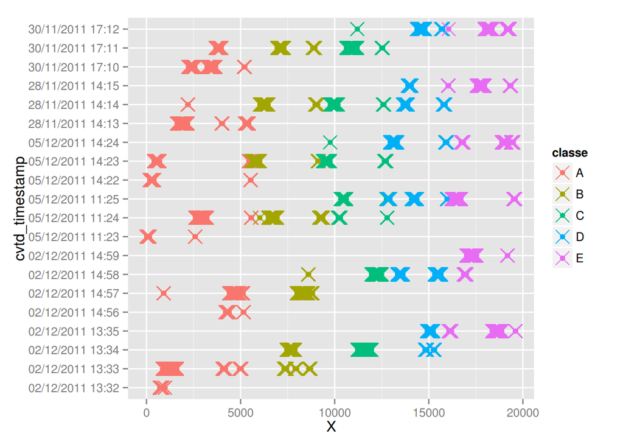

```r
p <- qplot(X,cvtd_timestamp,col=classe,data=training2)
p + geom_point(aes(x=X,y=cvtd_timestamp),size=5,shape=4,data=training2)
```

… it’s obvious that X and cvtd_timestamp are confounding variables, so we’ll have to remove them. It appears that there are a number of timestamps in the data which we’ll want to remove. X and timestamps are in the first 5 columns, so remove columns 1-5.

```r
training3 <- training2[,6:ncol(training2)] # remove X and timestamps
testing3 <- testing2[,6:ncol(testing2)] # remove X and timestamps
```

Now run the randomForest again and see which variables are now important.

```r
modRf <- randomForest(classe ~ .,na.action=na.omit,ntree=100,data=training3,prox=TRUE,importance=TRUE)
imp <- importance(modRf,type=1) # which features are important.
impdf <- data.frame(imp) # turn it into a data frame so..
impSub <- subset(impdf,MeanDecreaseAccuracy>0) # only relevant vars
impOrd <- data.frame(impSub[order(-impSub$MeanDecreaseAccuracy),,drop=FALSE])
head(impOrd,4) # gives us the 4 most important features.
```

```
##                    MeanDecreaseAccuracy
## var_accel_dumbbell             8.193129
## min_roll_forearm               8.191990
## avg_roll_dumbbell              6.832022
## num_window                     6.545673
```

Now look at how correlated the variables are to each other.

```r
M <- abs(cor(training3[,-ncol(training3)])) # remove outcomes (last column)
diag(M) <- 0 # remove diagonals
corrVar = which(M>0.9,arr.ind=T) # correlation > 0.9
out <- paste0("There are ", length(corrVar), " variables out of ", length(training3), " total with a correlation greater than 90%")
print(out)
```

```
## [1] "There are 48 variables out of 111 total with a correlation greater than 90%"
```

Some of the columns contain NAs, we will remove them from the training and testing sets now.

```r
naCols <- sapply(training3, function(x) {!any(is.na(x))}) # logical listing of those columnds w/o NAs
train3a <- training3[,naCols] # new set w/o NAs
test3a <- testing3[,naCols] # same for test set
```

It’s also clear that with this large number of correlated variables that a Principal Component Analysis can reduce the number of features. Due to computer constraints, this is required. Using a preprocessing of YeoJohnson “is similar to the Box-Cox model but can accommodate predictors with zero and/or negative values.”

```r
preProc <- preProcess(train3a[,-ncol(train3a)],method=c("YeoJohnson","pca"),thresh=0.95)
trainPre <- predict(preProc,train3a[,-ncol(train3a)])
```

Then take a look at only 2 principal components to see what kind of accuracy that might create

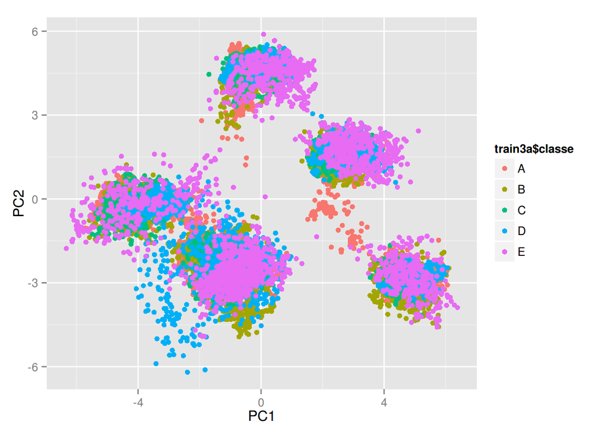

```r
p <- qplot(PC1,PC2,col=train3a$classe,data=trainPre)
p # interesting plot
```

Also process the testing data the same way.

```r
testPre <- predict(preProc,test3a[,-ncol(train3a)])
```

The following is a comparison of 4 different prediction models to see which one is best. First try a simple model of rpart

```r
#modelRpart <- train(trainPre,train3a$classe,method="rpart")
#saveRDS(modelRpart,"modelRpart.rds") #save the model
modelRpart <- readRDS("../Results/modelRpart.rds") #load the saved  model
predRpart <- predict(modelRpart,newdata=testPre)
cV1 <- confusionMatrix(predRpart,test3a$classe)
out <- paste0("The Rpart Model Accuracy is ",cV1[[3]][1])
print(out)
```

```
## [1] "The Rpart Model Accuracy is 0.382538377192982"
```

```r
#plot(cV1[[2]],main="Confusion Matrix - Rpart")
cV1[[2]] # in training error
```

```
##           Reference
## Prediction    A    B    C    D    E
##          A 1504  466  737  404  344
##          B    0    0    0    0    0
##          C    0    0    0    0    0
##          D  524  538  481  620  341
##          E   88  366   60  156  667
```

Next create a random forest model now and check its accuracy…

```r
#modFrf <- train(trainPre,train3a$classe,method="rf")
#saveRDS(modFrf,"modFrf.rds") #save the model
modFrf <- readRDS("../Results/modFrf.rds") # read saved model
predFrf <- predict(modFrf,newdata=testPre)
cVFrf <-confusionMatrix(predFrf,test3a$classe)
out <- paste0("The Random Forest Model Accuracy is ",cVFrf[[3]][1])
print(out)
```

```
## [1] "The Random Forest Model Accuracy is 0.979303728070175"
```

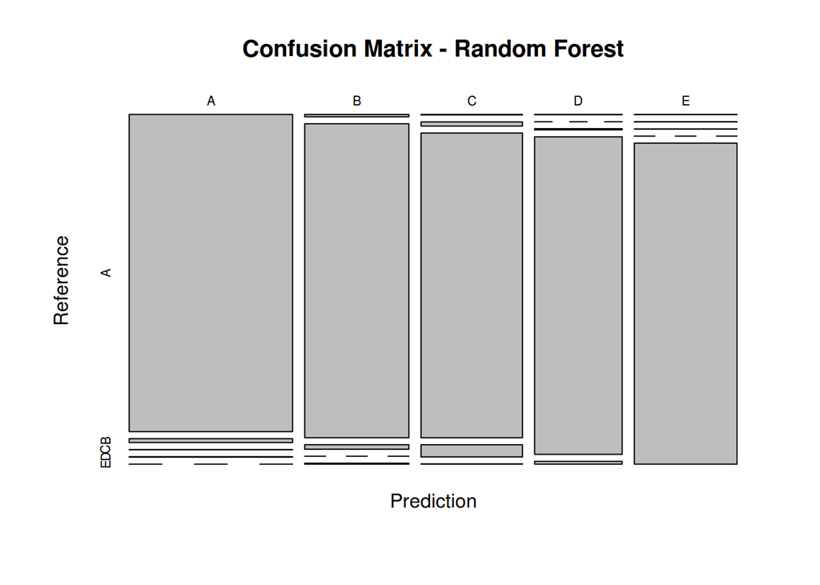

```r
plot(cVFrf[[2]],main="Confusion Matrix - Random Forest")
```

```r
cVFrf[[2]] # in training error
```

```
##           Reference
## Prediction    A    B    C    D    E
##          A 2102   26    1    3    0
##          B   10 1326   19    0    4
##          C    2   17 1253   50    1
##          D    1    0    4 1127   10
##          E    1    1    1    0 1337
```

Take a look at what this model thinks is important.

```r
imp <- importance(modFrf$finalModel,type=1) # which features are important.
impdf <- data.frame(modFrf$finalModel$importance) # turn it into a data frame so..
impSub <- subset(impdf,MeanDecreaseGini>0) # only relevant vars
impOrd <- data.frame(impSub[order(-impSub$MeanDecreaseGini),,drop=FALSE])
head(impOrd,4) # gives us the 4 most important features.
```

```
##      MeanDecreaseGini
## PC16         713.7273
## PC7          712.2830
## PC1          694.5145
## PC3          688.4900
```

Next create a boosted (Ada) model now and check its accuracy

```r
#modFAb <- train(trainPre,train3a$classe,method="AdaBoost.M1")
#saveRDS(modFAb,"modFAb.rds") #save the model
modFAb <- readRDS("../Results/modFAb.rds") # read saved model
predFAb <- predict(modFAb,newdata=testPre)
cVFAb <-confusionMatrix(predFAb,test3a$classe)
out <- paste0("The Boosted Ada Model Accuracy is ",cVFAb[[3]][1])
print(out)
```

```
## [1] "The Boosted Ada Model Accuracy is 0.776315789473684"
```

```r
#plot(cVFAb[[2]],main="Confusion Matrix - Boosted Ada")
cVFAb[[2]] # in training error
```

```
##           Reference
## Prediction    A    B    C    D    E
##          A 1691  115   43  100   40
##          B  146 1058  159   39  107
##          C  147  126  971  123   75
##          D   92   28   91  872   58
##          E   40   43   14   46 1072
```

Finally create a SVM model and check its accuracy

```r
#modFSvm <- train(trainPre,train3a$classe,method="svmLinear")
#saveRDS(modFSvm,"modFSvm.rds") #save the model
modFSvm <- readRDS("../Results/modFSvm.rds") # read saved model
predFSvm <- predict(modFSvm,newdata=testPre)
cVFSvm <-confusionMatrix(predFSvm,test3a$classe)
out <- paste0("The Support Vector Matrix Model Accuracy is ",cVFSvm[[3]][1])
print(out)
```

```
## [1] "The Support Vector Matrix Model Accuracy is 0.622121710526316"
```

```r
#plot(cVFSvm[[2]],main="Confusion Matrix - SVM")
cVFSvm[[2]] # in training error
```

```
##           Reference
## Prediction    A    B    C    D    E
##          A 1555  309  183  140  135
##          B  105  690  117   43  246
##          C  169  158  848  141  151
##          D  238  101  110  791  165
##          E   49  112   20   65  655
```

The following table and graph show the accuracy and the out of sample total errors for each model

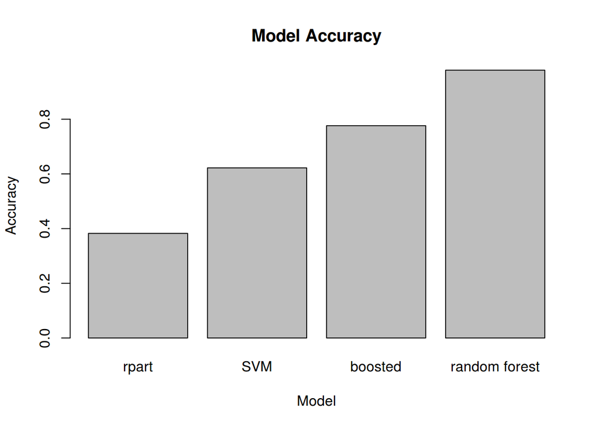

```r
resultnames <- c("rpart","SVM","boosted","random forest")
results.df <- data.frame(row.names=resultnames);
accuracy <- c(cV1[[3]][1],cVFSvm[[3]][1],cVFAb[[3]][1],cVFrf[[3]][1])
results.df$Accuracy <- accuracy
oosRpart <- cV1[[2]]
diag(oosRpart) <- 0
oosRpart <- sum(oosRpart)
oosB <- cVFAb[[2]]
diag(oosB) <- 0
oosB <- sum(oosB)
oosSVM <- cVFSvm[[2]]
diag(oosSVM) <- 0
oosSVM <- sum(oosSVM)
oosRf <- cVFrf[[2]]
diag(oosRf) <- 0
oosRf <- sum(oosRf)
ooS <- c(oosRpart,oosSVM,oosB,oosRf)
results.df$Out_Of_Sample <- ooS
barplot(results.df$Accuracy, main="Model Accuracy",xlab="Model",ylab="Accuracy",names.arg=row.names(results.df))
```

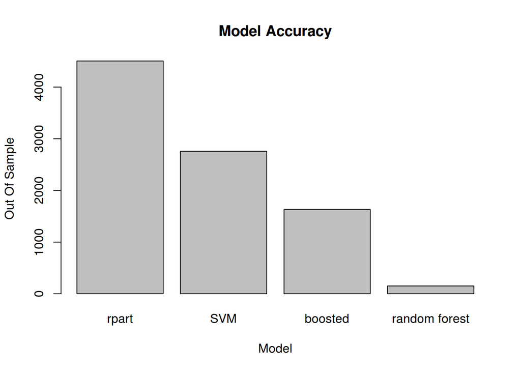

```r
barplot(results.df$Out_Of_Sample, main="Model Accuracy",xlab="Model",ylab="Out Of Sample",names.arg=row.names(results.df))
```

```r
print.data.frame(results.df,digits=2)
```

```
##               Accuracy Out_Of_Sample
## rpart             0.38          4505
## SVM               0.62          2757
## boosted           0.78          1632
## random forest     0.98           151
```

In conclusion the Random Forest Model is clearly superior to the other 3. It has an accuracy of 98% and only 151 out of sample errors in a test set size of 7,296 measurements.